# Lab 12

Steven Cabrera

2022-11-16

## PCA

1. For each 1 cm increase in body length, we observed a 0.065 (+/- 0.18 C.I.) increase in predation (p = 0.49). **non-significant result**  
   For each 1 kg increase in mass, we observed a 0.067 (+/- 0.17 C.I.) decrease in predation (p = 0.43). **non-significant result**  
   For each 1 cm increase in hind-foot length, we observed a 0.18 (+/- 0.32 C.I.) decrease in predation (p = 0.27). **non-significant result**  
   For each 1 cm increase in tail-length, we observed a 0.11 (+/- 0.18 C.I.) increase in predation (p = 0.24). **non-significant result**
2. Run PCA.
3. PC1 = 0.991 / PC2 = 0.004 / PC3 = 0.002 / PC4 = 0.001
4. PC1 is characterized by animals with long body length, long tails, large masses, and long hind foot length - so maybe a Great Pyrenees.  
   PC2 is characterized low mass and long tails - so maybe a chihauhau.  
   PC3 is characterized by long body length, low mass, long hind foot length, and short tails - so maybe a Samuel Krebsbach.  
   PC4 is characterized by long body length, short hind foot length, and short tail lengths - so maybe a weiner dog.
5. Run the lm of predation and PC scores.
6. PC1 is the only significant factor in this lm (p <2e-16). PC2 (p = 0.17), PC3 (p = 0.55), PC4 (p = 0.31) are all **non-significant results**.

## DFA

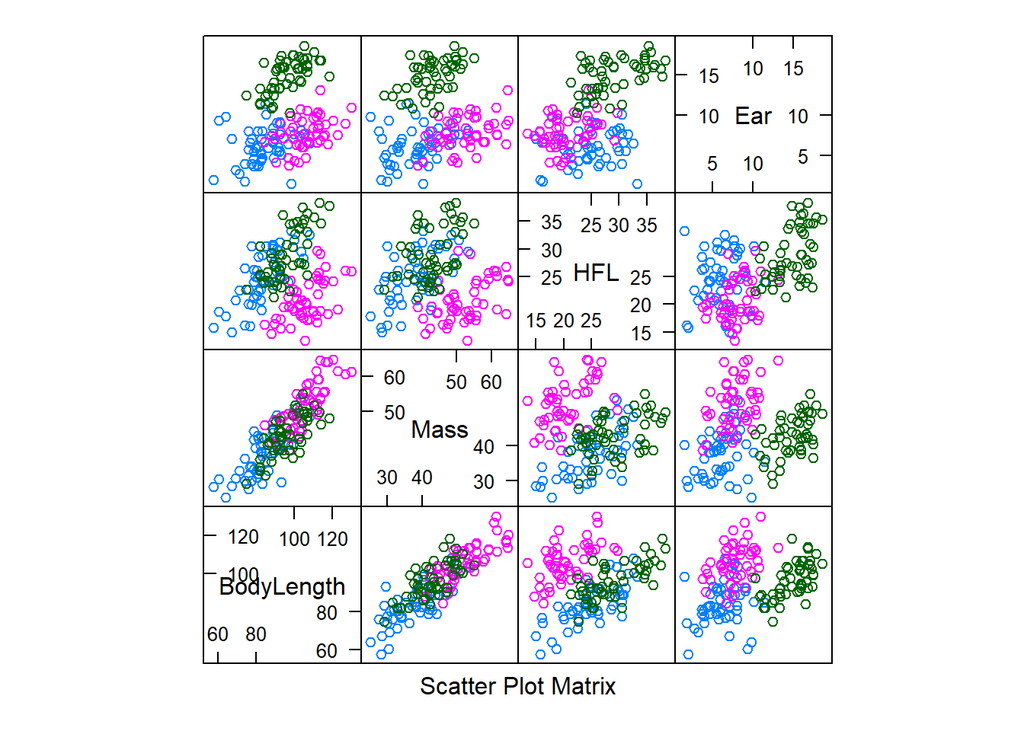

2. MANOVA F-statistic is 116.08. Body length (p < 2.2e-16), mass (p < 2.2e-16), hind-foot length (4.8e-16), and ears (p < 2.2e-16) are all significant among the three groups.
3. Coyotes have short body lengths, lower masses, intermediate hind-food lengths, and short ears.  
   Grey wolves have long bodies, higher masses, short hind-foot lengths, and short ears.  
   Red wolves have large bodies, intermediate masses, long hind-foot lengths, and long ears.
4. LD1 is associated with shorter bodies, lower masses, long hind-foot lengths, and long ears.  
   LD2 is associated with longer body sizes, higher masses, shorter hind-foot lengths, and long ears.
5. The proportion of trace determined by LD1 is 0.7086.
6. The DFA did very well predicting class membership. 48/49 of coyotes and grey wolves were predicted correctly, and 49/51 red wolves were predicted correctly. See table below.

```
##
##            Coyote GreyWolf RedWolf
##   Coyote       48        0       2
##   GreyWolf      1       48       0
##   RedWolf       0        1      49
```

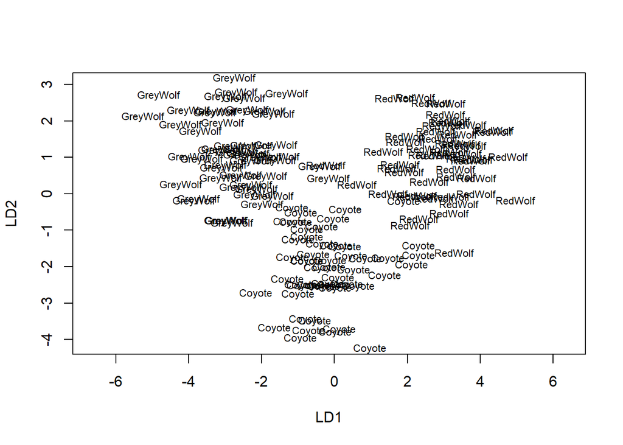